# RSE Skills

(in Python)

Jack Atkinson

ICCS RSE Team  
University of Cambridge

Marion Weinzierl

ICCS RSE Team  
University of Cambridge

2026-07-13

## Precursors

#### Slides and Materials

To access links or follow on your own device these slides can be found at:  
[jatkinson1000.github.io/rse-skills-workshop](https://jatkinson1000.github.io/rse-skills-workshop/)

All materials are available at:

- github.com/jatkinson1000/rse-skills-workshop
- gitlab.com/jatkinson1000/rse-skills-workshop

:

:

## Precursors

#### Behaviour

- Be nice ([Python code of conduct](https://www.python.org/psf/conduct/))
- Ask questions whenever they arise.
  - Someone else is probably wondering the same thing.
- We will make mistakes.
  - Not all of them will be intentional.

#### Licensing

Except where otherwise noted, these presentation materials are licensed under the Creative Commons [Attribution-NonCommercial 4.0 International](https://creativecommons.org/licenses/by-nc/4.0/legalcode) ([CC BY-NC 4.0](https://creativecommons.org/licenses/by-nc/4.0/)) License.

[figure not shown]

Vectors and icons by [SVG Repo](https://www.svgrepo.com) used under [CC0(1.0)](https://creativecommons.org/publicdomain/zero/1.0/deed.en)

## Course structure

- Why good SE matters in research
- How to apply these everyday to write higher quality code
  - Core principles
  - Key tools
  - Useful techniques
- Tooling for better research software
  - venv for virtual environments
  - formatting and linting - best practices
  - structuring code
- Writing better research software
  - comments and docstrings
  - repository documentation - licenses, README
  - Other (naming, magic numbers,…)

## What is Research Software?

Major Computational Programs

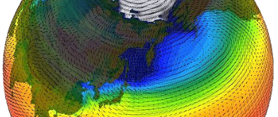

[figure not shown]

Data processing

[figure not shown]

Experiment support

[figure not shown]

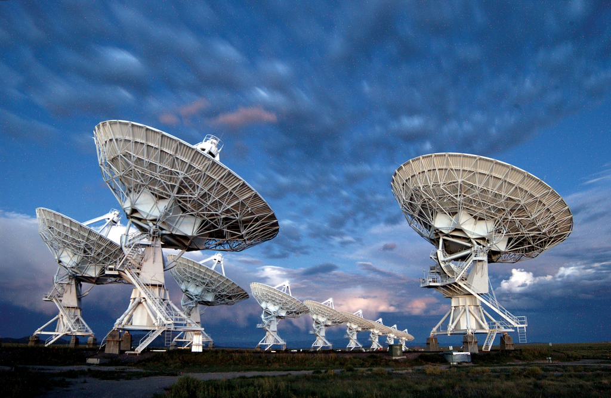

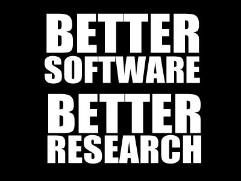

VLA Telescope by NROA under public domain CTD Bottles by WHOI under public domain  
Keeling Curve by Scripps under public domain  
Dawn HPC by Joe Bishop with permission  
Climate simulation by NSF under public domain

## Why does this matter?

[figure not shown]

## Why does this matter?

More widely than publishing papers, code is used in control and decision making:

- Weather forecasting
- Climate policy
- Disease modelling (e.g. Covid)
- Satellites and spacecraft<sup>1</sup>
- Medical Equipment

Your code (or its derivatives) may well move from research to operational one day.

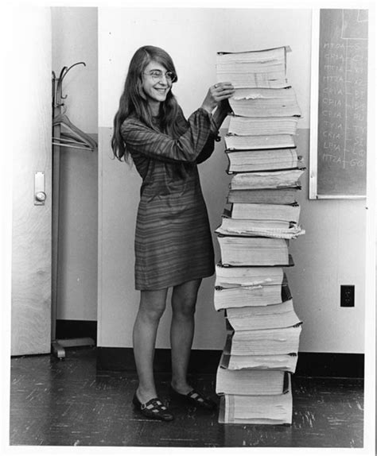

Margaret Hamilton and the Apollo XI by NASA under public domain

[^1]: If possible to be even more awesome, it was MH [who first coined the term *“Software Engineering”*](https://www.computer.org/publications/tech-news/events/what-to-know-about-the-scientist-who-invented-the-term-software-engineering).]

## Why does this matter?<sup>1</sup>

```python
def calc_p(n,t):
    return n*1.380649e-23*t
data = np.genfromtxt("mydata.csv")
p = calc_p(data[0,:],data[1,:]+273.15)
print(np.sum(p)/len(p))
```

What does this code do?

```python
# Boltzmann Constant and 0 Kelvin
Kb = 1.380649e-23
T0 = 273.15

def calc_pres(n, t):
    """
    Calculate pressure using ideal gas law p = nkT

    Parameters:
        n : array of number densities of molecules [N m-3]
        t : array of temperatures in [K]
    Returns:
         array of pressures [Pa]
    """
    return n * Kb * t


# Read in data from file and convert T from [oC] to [K]
data = np.genfromtxt("mydata.csv")
n = data[0, :]
temp = data[1, :] + T0

# Calculate pressure, average, and print
pres = calc_pres(n, temp)
pres_av = np.sum(pres) / len(pres)
print(pres_av)
```

[^2]: For more details I highly recommend the [Writing Clean Scientific Software](https://www.youtube.com/watch?v=Q6Ksu_uX3bc) Webinar (Murphy 2023)

# Virtual Environments

## Virtual Environments

#### What?

- A self-contained Python environment
- Packages installed in a local folder
- Advised to use on a per-project basis

#### Why?

- Avoid system pollution through isolation
- Allow different versions for different projects
- Reproducibility - set versions

For more information see the [Real Python article](https://realpython.com/python-virtual-environments-a-primer/) on virtual environments.

## Virtual Environments - `venv`

Python has inbuilt support for creating isolated virtual environments through [`venv`](https://docs.python.org/3/library/venv.html).

- Linux/macOS
- Windows Powershell
- Windows cmd.exe

```
$ python3 -m venv rse-venv
$ source rse-venv/bin/activate
(rse-venv) $ pip install <packagename>
(rse-venv) $ deactivate
$
```

```
PS> python -m venv rse-venv
PS> rse-venv\Scripts\Activate.ps1
(rse-venv) PS> pip install <packagename>
(rse-venv) PS> deactivate
PS>
```

```
C:\> python -m venv rse-venv
C:\> rse-venv\Scripts\activate.bat
(rse-venv) C:\> pip install <packagename>
(rse-venv) C:\> deactivate
C:\>
```

You will see that a directory `rse-venv/` has been created.  
Pip will install dependencies into this directory.  
To remove the venv we delete this directory with `rm -r rse-venv` on Unix, or `rmdir /s rse-venv` on Windows.

## Other Languages

There are various other tools available to manage dependencies:

- Python and more - conda
- C, C++, Fortran:
  - Module environments
  - Spack
- Rust - cargo
- Julia - Pkg environments
- R - renv

## Exercise 1

- Geoscience
- Astrophysics

Scenario: you have just finished some simulations with a climate model that should improve precipitation modelling and have the output data as a netCDF file.

You know that your colleague has produced relevant figures and analysis before, so ask them for a copy of their code (yay, reuse :+1:).

Go to exercise 1 and examine the code in `geo.py`.

Scenario: you have just finished preparing a new stellar dataset in a csv file and want to visualise the data to see what it tells you.

You know that your colleague has produced relevant figures and analysis for similar data before, so ask them for a copy of their code (yay, reuse :+1:).

Go to exercise 1 and examine the code in `astro.py`

- Create and load a virtual environment
- Install the necessary dependencies
- Run the code - does it do what you thought?
- Deactivate the environment

## Basic packaging concepts

Code/software will often have several dependencies required to run.

Provide a record of these to users to save time and errors when installing.

Recorded in a `requirements.txt` file:

- list of required packages to be installed by pip
- typically specify top-level, not subdependencies
- can enforce version constraints

`requirements.txt`

```
netcdf4
xarray
scipy==1.13.1
numpy<2.0
cartopy
```

```
(rse-venv) $ pip install -r requirements.txt
```

We can improve and streamline this process even further through packaging, but this is beyond the scope of this discussion.

We can use `pip freeze` to get a list of all dependencies and versions, though this includes subdependencies.

## Exercise 1 revisited

- Geoscience
- Astrophysics

Scenario: you have just finished some simulations with a climate model that should improve precipitation modelling and have the output data as a netCDF file.

You know that your colleague has produced relevant figures and analysis before, so ask them for a copy of their code (yay, reuse :+1:).

Go to exercise 1 and examine the code in `geo.py`.

Scenario: you have just finished preparing a new stellar dataset in a csv file and want to visualise the data to see what it tells you.

You know that your colleague has produced relevant figures and analysis for similar data before, so ask them for a copy of their code (yay, reuse :+1:).

Go to exercise 1 and examine the code in `astro.py`

- Create and load a virtual environment
- Install the requirements from the supplied `requirements.txt`
- Run the code - does it do what you thought?
- Deactivate the environment

# PEP8 and Formatting

## Python PEPs

[Python Enhancement Proposals](https://peps.python.org/)

- Technical documentation for the python community
- Guidelines, standards, and best-practice

Relevant to us today are:

- PEP8 - Python Style Guide (Rossum et al. 2001, 2013)
- PEP257 - Docstring Conventions (Goodger and Rossum 2001)
- PEP621 - Packaging (Cannon et al. 2020)

## PEP8 & Formatting

> *“Readability counts”*  
> - Tim Peters in the [Zen of Python](https://peps.python.org/pep-0020/)

By ensuring code aligns with PEP8 we:

- standardise style,
- conform to best-practices, and
- improve code readability to
- make code easier to share, and
- reduce misinterpretation.

“But I don’t have time to read and memorise all of this…”

## PEP8 & Formatting - Ruff

[figure not shown]

Ruff (Astral 2025) - [docs.astral.sh/ruff](https://docs.astral.sh/ruff/)

- a PEP 8 compliant formatter
  - Strict subset of PEP8
  - *“Opinionated so you don’t have to be.”*
- For full details see [style guide](https://docs.astral.sh/ruff/formatter/#style-guide)
- [Try online](https://play.ruff.rs/?secondary=Format)
- Linux/macOS
- Windows

```
(rse-venv) $ pip install ruff
(rse-venv) $ ruff format myfile.py
(rse-venv) $ ruff format mydirectory/
```

```
(rse-venv) PS> pip install ruff
(rse-venv) PS> ruff format myfile.py
(rse-venv) PS> ruff format mydirectory/
```

## PEP8 & Formatting - Example

```python
def long_func(x, param_one, param_two=[], param_three=24, param_four=None,
        param_five="Empty Report", param_six=123456):


    val = 12*16 +(24) -10*param_one +  param_six

    if x > 5:

        print("x is greater than 5")


    else:
        print("x is less than or equal to 5")


    if param_four:
        print(param_five)



    print('You have called long_func.')
    print("This function has several params.")

    param_2.append(x*val)
    return param_2
```

```python
def long_func(
    x,
    param_one,
    param_two=[],
    param_three=24,
    param_four=None,
    param_five="Empty Report",
    param_six=123456,
):
    val = 12 * 16 + (24) - 10 * param_one + param_six

    if x > 5:
        print("x is greater than 5")

    else:
        print("x is less than or equal to 5")

    if param_four:
        print(param_five)

    print("You have called long_func.")
    print("This function has several params.")

    param_2.append(x * val)
    return param_2
```

## PEP8 & Formatting - Ruff

- Also runs on jupyter notebooks.
- Highly configurable via configuration files.
- I suggest incorporating into your projects now
  - Widely-used standard<sup>1</sup>
  - Plugins/lsp available for many editors.
  - Well suited to incorporation into continuous integration through workflows and git hooks.
[^3]: [Who’s Using Ruff?](https://github.com/astral-sh/ruff#whos-using-ruff)

## Other languages

Similar formatting tools exist for other languages:

- Python - [ruff](https://docs.astral.sh/ruff/) or [black](https://black.readthedocs.io/en/stable/index.html)
- C and C++ - [clang-format](https://clang.llvm.org/docs/ClangFormat.html)
- Fortran - fortitude (in development)
- Rust - rustfmt
- Julia - JuliaFormatter.jl
- R - styler or [Air](https://github.com/posit-dev/air)

## Exercise 2

Go to exercise 2 and:

- install ruff
- run `ruff format` on the Python code.
- examine the output
  - Is it more readable?
  - Is there any aspect of the formatting style you find unintuitive?
- See `exercises/02_formatting/README.md` for more detailed instructions.

# Static Analysis

## Static Analysis

Beyond PEP8:

- Improve code quality
- Learn better practices

Save time and resource:

- Check code for issues without running

There are various tools available:

- ruff
- Pylint
- flake8
- pycodestyle

We will be using `ruff check` for static analysis, which we already installed as part of `ruff` in a previous exercise.

## Code Quality - `ruff check`

```python
def long_func(
    x,
    param_one,
    param_two=[],
    param_three=24,
    param_four=None,
    param_five="Empty Report",
    param_six=123456,
):
    val = 12 * 16 + (24) - 10 * param_one + param_six

    if x > 5:
        print("x is greater than 5")

    else:
        print("x is less than or equal to 5")

    if param_four:
        print(param_five)

    print("You have called long_func.")
    print("This function has several params.")

    param_2.append(x * val)
    return param_2
```

## Code Quality - `ruff check`

```python
def long_func(
    x,
    param_one,
    param_two=[],
    param_three=24,
    param_four=None,
    param_five="Empty Report",
    param_six=123456,
):
    val = 12 * 16 + (24) - 10 * param_one + param_six

    if x > 5:
        print("x is greater than 5")

    else:
        print("x is less than or equal to 5")

    if param_four:
        print(param_five)

    print("You have called long_func.")
    print("This function has several params.")

    param_2.append(x * val)
    return param_2
```

```
(rse-venv) $ ruff check long_func.py
long_func.py:4:5: ARG001 Unused function argument: `param_two`
long_func.py:4:15: B006 Do not use mutable data structures for argument defaults
long_func.py:5:5: ARG001 Unused function argument: `param_three`
long_func.py:24:5: F821 Undefined name `param_2`
long_func.py:25:12: F821 Undefined name `param_2`
Found 5 errors.

(rse-venv) $
```

Note:  
use the `--output-format=concise`  
flag for this shortened output.

## Code Quality - `ruff check`

```python
def long_func(
    x,
    param_one,
    param_two=[],
    param_four=None,
    param_five="Empty Report",
    param_six=123456,
):
    val = 12 * 16 + (24) - 10 * param_one + param_six

    if x > 5:
        print("x is greater than 5")

    else:
        print("x is less than or equal to 5")

    if param_four:
        print(param_five)

    print("You have called long_func.")
    print("This function has several params.")

    param_two.append(x * val)
    return param_two
```

```
(rse-venv) $ ruff check long_func.py
long_func.py:4:15: B006 Do not use mutable data structures for argument defaults
Found 1 errors.

(rse-venv) $
```

Use `ruff rule` to understand different rules:

```
ruff rule B006
```

will display the [docs for B006](https://docs.astral.sh/ruff/rules/mutable-argument-default/)

## IDE Integration

- Catch issues before running ruff
- Gradually coerces you to become a better programmer
- See [ruff editor integration docs](https://docs.astral.sh/ruff/editors/setup/) for instructions on setup for:
  - Vim
  - pycharm
  - Sublime
  - VS Code
  - Emacs

## Other languages

Similar tools for linting and static analysis exist for other languages:

- C and C++ - [clang-tidy](https://clang.llvm.org/extra/clang-tidy/) and [cppcheck](https://cpp-linter.github.io/)
- Fortran - fortitude
- Rust - [clippy](https://doc.rust-lang.org/clippy/)
- R - [lintr](https://lintr.r-lib.org/)

More generally see [this list of static analysis tools](https://github.com/analysis-tools-dev/static-analysis).

## Exercise 3

- Geoscience
- Astrophysics

Go to exercise 3 and:

- run `ruff check` on `geo.py`
- examine the report and try and address some of the issues.
  - Try and deal with: `F401` unused imports, `I001` unsorted imports, `B006` dangerous default, and `D202` Blank lines
  - For a challenge try and fix: `B904` try exceptions and `RUF059` unused unpack

Go to exercise 3 and:

- run `ruff check` on `astro.py`
- examine the report and try and address some of the issues.
  - Try and deal with: `F401` unused imports, `I001` unsorted imports, `B006` dangerous default, and `D202` Blank lines
  - For a challenge try and fix: `A001` shadowing, and `PLR1714` merging comparisons.
  - Ignore `F841` for now as we will address it in a later exercise.

Extensions:

- explore autofixes using the `--fix` flag
- explore rules in development using the `--preview` flag
- try and add linting to your preferred text editor or IDE

## Configuration

The default set of linting rules for ruff is quite simple.

The ruleset to be applied can be configured in a `ruff.toml` file, as we do in this project, or `pyproject.toml` for packaged code.  
For full details see the [ruff configuration documentation](https://docs.astral.sh/ruff/configuration/).

Details of the different rules and rulesets that can be selected can be found in the [ruff rules documentation](https://docs.astral.sh/ruff/rules/).

Let’s take a look and make some changes in preparation for the next sections:

- We will add the entire `"D"` (pydocstyle) ruleset, extending to `D417`.
- We will stop ignoring:
  - `"PLR2004"` (magic number comparisons) and
  - `"E501"` (line length).
  - `"E741"` (ambiguous name).

# Structuring your code

## Functions

- Avoid code duplication
  - Bad style
  - You will forget to update all the copies at one point when you make changes!
- Readability
  - A clearly named function replaces a chunk of code.
- Functions as building blocks
  - Create generic interface with several exchangeable options (e.g. “possion_solver”, “gauss_seidel_solver”, etc.)
  - Separation of concerns/single responsibility principles

## Functions for readability and maintainability

```python
"""Module implementing pendulum equations."""
import numpy as np

def max_speed(l, theta):
    """..."""
    return np.sqrt(2.0 * 9.81 *  l * np.cos(theta))

def energy(m, l, theta):
    """..."""
    return m * 9.81 * l * np.cos(theta)

def check_small_angle(theta):
    """..."""
    if theta <= np.pi / 1800.0:
        return True
    return False

def bpm(l):
    """..."""
    return 60.0 / 2.0 * np.pi * np.sqrt(l / 9.81)
```

```python
"""Module implementing pendulum equations."""
import numpy as np

GRAV = 9.81

def get_period(l):
    """..."""
    return 2.0 * np.pi * np.sqrt(l / GRAV)

def max_height(l, theta):
    """..."""
    return l * np.cos(theta)

def max_speed(l, theta):
    """..."""
    return np.sqrt(2.0 * GRAV * max_height(l, theta))

def energy(m, l, theta):
    """..."""
    return m * GRAV * max_height(l, theta)

def check_small_angle(theta, small_ang=np.pi/1800.0):
    """..."""
    if theta <= small_ang:
        return True
    return False

def bpm(l):
    """..."""
    # Divide 60 seconds by period [s] for beats per minute
    return 60.0 / get_period(l)
```

## Further structuring

- Breaking code into modules and files instead of having everything in one file
- Improves readability and manageability (-> scalability, extendability, coupling, testing)

## Exercise 4

- Go to Exercise 4 and try to think of how you can structure the code in the plotting.py file to avoid code duplication, and improve readability and reusability.
- What enables the improved code you to do?
- Now look at plotting_solution.py . Can you further adapt the code to allow, for example, for customised axis labels?

# RSE Skills Day 2

Jack Atkinson and Marion Weinzierl

ICCS RSE

## RSE Skills - Day 2

Welcome back.

Today we will cover making software easier to read and use through:

- comments,
- documentation,
- naming, and
- repository structuring.

#### Slides and Materials

To access links or follow on your own device these slides can be found at:  
[jatkinson1000.github.io/rse-skills-workshop](https://jatkinson1000.github.io/rse-skills-workshop/)

:

:

# Naming Clarity and Magic Numbers

## Naming for clarity

It may seem inconsequential, but carefully naming variables and methods can greatly improve the readability of code.

Since *“code is read more than it is run”* this is important for future you, but also for anyone you collaborate with or who might use your code in future.

It helps to make code self-documenting, reducing future bugs due to misunderstandings.

Here we cover some key considerations when writing code.

## Naming for clarity

- Show the intention – how will someone else (future you) read it?
- Use readable, pronounceable, memorable, and searchable names:

  ```
  ms    --> mass
  chclt --> chocolate
  stm   --> stem
  ```

  avoid abbreviations and single letters unless commonly used
- Employ concept consistency  
  e.g. only one of `get_`, `retrive_`, `fetch_` in the code base
- Describe content rather than storage type  
  Use plurals to indicate groups  
  Name booleans using prefixes like `is_`, `has_`, `can_` and avoid negations like `not_`:

  ```
  array       --> dogs                    float_or_int --> returns_int
  age_int     --> age                     not_plant    --> is_plant
  country_set --> countries               sidekick     --> has_sidekick
  ```

## Explaining Variables

Without explaining variable:

```python
def calculate_fare(age):
    if (age < 14):
        return 3
        ...
```

With explaining variable:

```python
def calculate_fare(age):
    is_child = age < 14
    if (is_child):
        return 3
    ...
```

## Explaining Variables

Without an explaining variable, it is hard to see what this code is doing:

```python
import re

re.search("^\\+?[1-9][0-9]{7,14}$", "Sophie: CV56 9PQ, +12223334444")
```

With explaining variables it is easier to see the intention.  
The code is more self-documenting.

```python
import re

phone_number_regex = "^\\+?[1-9][0-9]{7,14}$"
re.search(phone_number_regex, "Sophie: CV56 9PQ, +12223334444")
```

## Magic Numbers

Numbers in code that are not immediately obvious.

- Hard to read
- Hard to maintain
- Hard to adapt

Instead:

- Name a variable conveying meaning
- Set to a constant
- Use a comment to explain

[figure not shown]

numberwang by Mitchell and Webb under fair use

## Handling Magic Numbers

```python
"""Module implementing pendulum equations."""
import numpy as np

def get_period(l):
    """..."""
    return 2.0 * np.pi * np.sqrt(l / 9.81)

def max_height(l, theta):
    """..."""
    return l * np.cos(theta)

def max_speed(l, theta):
    """..."""
    return np.sqrt(2.0 * 9.81 * max_height(l, theta))

def energy(m, l, theta):
    """..."""
    return m * 9.81 * max_height(l, theta)

def check_small_angle(theta):
    """..."""
    if theta <= np.pi / 1800.0:
        return True
    return False

def beats_per_minute(l):
    """..."""
    return 60.0 / get_period(l)
```

```python
"""Module implementing pendulum equations."""
import numpy as np

GRAV = 9.81

def get_period(l):
    """..."""
    return 2.0 * np.pi * np.sqrt(l / GRAV)

def max_height(l, theta):
    """..."""
    return l * np.cos(theta)

def max_speed(l, theta):
    """..."""
    return np.sqrt(2.0 * GRAV * max_height(l, theta))

def energy(m, l, theta):
    """..."""
    return m * GRAV * max_height(l, theta)

def check_small_angle(theta, small_ang=np.pi/1800.0):
    """..."""
    if theta <= small_ang:
        return True
    return False

def beats_per_minute(l):
    """..."""
    # Divide 60 seconds by period [s] for beats per minute
    return 60.0 / get_period(l)
```

## Exercise 5

Look through the code for method or variable names that could be improved or clarified and update them.<sup>1</sup>

Look through the code and identify any magic numbers.  
Implement what you feel to be the best approach in each case.

Does this make the code easier to follow?

Consider the following, can you find an example of each:

- Show the intention – how will someone else (future you) read it
- Use readable, pronounceable, memorable, and searchable names
- Keep it simple using technical terms where appropriate
- Employ concept consistency in the code base
- Describe content rather than type
- Use plurals to indicate groups
- Name booleans using prefixes
- Use explaining variables
[^4]: Note: if you are using an IDE like Intellij or VSCode you can use automatic renaming.

# Comments and Docstrings

## Comments

Comments are tricky, and very much to taste.

Some thoughts:<sup>1</sup>

> “Programs must be written for people to read and […] machines to execute.”  
> - Hal Abelson

> “A bad comment is worse than no comment at all.”

> “A comment is a lie waiting to happen.”

=> Comments have to be maintained, just like the code, and there is no way to check them!

[figure not shown]

Cat code comment image by [35_equal_W](https://www.reddit.com/r/ProgrammerHumor/comments/8w54mx/code_comments_be_like/)

[^5]: Stackoverflow blog (Spertus 2021), and [RealPython comments lesson](https://realpython.com/lessons/importance-writing-good-code-comments/)

## Comments to avoid

- Dead code e.g.

  ```python
  # plt.plot(time, velocity, "r0")
  plt.plot(time, velocity, "kx")
  # plt.plot(time, acceleration, "kx")
  # plt.ylabel("acceleration")
  plt.ylabel("velocity")
  ```

- Variable definitions e.g.

  ```python
  # Set Force
  f = m * a
  ```

- Redundant comments e.g. `i += 1 # Increment i`

## Comments - some thoughts<sup>1</sup>

- Comments should not duplicate the code.
- Good comments do not excuse unclear code.
  - Comments should dispel confusion, not cause it.
  - If you can’t write a clear comment, there may be a problem with the code.
- Explain unidiomatic code in comments.
- Provide links to:
  - the original source of copied code.
  - external references where they will be most helpful.
- Use comments to mark incomplete implementations.
- Comments are not documentation.
  - Read by developers, documentation is for…
[^6]: Adapted from (Spertus 2021)

## Docstrings

**These are what make your code reusable (by you and others).**

- In python docstrings are designated at the start of *‘things’* using triple quotes: `"""..."""`.
- PEP257 (Goodger and Rossum 2001) tells us *what* docstrings should say.  
  Specific conventions tell us *how* they should say it.
- Where comments describe how it *works*, docstrings describe how to *use* it.  
  Unlike comments, docstrings follow a set format.

Various formatting options exist: numpy, Google, reST, etc.  
We will follow numpydoc as it is readable and widely used in scientific code.  
Full guidance for [numpydoc is available](https://numpydoc.readthedocs.io/en/latest/format.html).

## Docstrings

Key components:

- A description of what the thing is.
- A description of any inputs (`Parameters`).
- A description of any outputs (`Returns`).

Consider also:

- Extended summary
- Errors raised
- Usage examples
- Key references

```python
"""
Short one-line description.

Parameters
----------
name : type
    description of parameter

Returns
-------
name : type
    description of return value
"""
```

## Docstrings

Key components:

- A description of what the thing is.
- A description of any inputs (`Parameters`).
- A description of any outputs (`Returns`).

```python
def calculate_gyroradius(mass, v_perp, charge, B, gamma=None):
    """
    Calculates the gyroradius of a charged particle in a magnetic field

    Parameters
    ----------
    mass : float
        The mass of the particle [kg]
    v_perp : float
        velocity perpendicular to magnetic field [m/s]
    charge : float
        particle charge [coulombs]
    B : float
        Magnetic field strength [teslas]
    gamma : float, optional
        Lorentz factor for relativistic case. default=None for non-relativistic case.

    Returns
    -------
    r_g : float
        Gyroradius of particle [m]

    Notes
    -----
    .. [1]  Walt, M, "Introduction to Geomagnetically Trapped Radiation,"
       Cambridge Atmospheric and Space Science Series, equation (2.4), 2005.
    """

    r_g = mass * v_perp / (abs(charge) * B)

    if gamma:
        r_g = r_g * gamma

    return r_g
```